# Problem Statement - Description

# Background and Context

Businesses like banks that provide service have to worry about the problem of 'Churn' i.e. customers leaving and joining another service provider. It is important to understand which aspects of the service influence a customer's decision in this regard. Management can concentrate efforts on the improvement of service, keeping in mind these priorities.

# Objective

Given a Bank customer, build a neural network-based classifier that can determine whether they will leave or not in the next 6 months.

# Data Description

The case study is from an open-source dataset from Kaggle. The dataset contains 10,000 sample points with 14 distinct features such as CustomerId, CreditScore, Geography, Gender, Age, Tenure, Balance, etc.

# Data Dictionary

• CustomerId: Unique ID which is assigned to each customer

• Surname: Last name of the customer

• CreditScore: It defines the credit history of the customer.

• Geography: A customer’s location

• Gender: It defines the Gender of the customer

• Age: Age of the customer

• Tenure: Number of years for which the customer has been with the bank

• NumOfProducts: It refers to the number of products that a customer has purchased through the bank.

• Balance: Account balance

• HasCrCard: It is a categorical variable that decides whether the customer has a credit card or not.

• EstimatedSalary: Estimated salary

• isActiveMember: It is a categorical variable that decides whether the customer is an active member of the bank or not ( Active member in the sense, using bank products regularly, making transactions, etc )

• Exited: It is a categorical variable that decides whether the customer left the bank within six months or not.

It can take two values

```
                0=No ( Customer did not leave the bank )


                1=Yes ( Customer left the bank )
```

```python
# this will help in making the Python code more structured automatically (good coding practice

%load_ext nb_black
```

```
The nb_black extension is already loaded. To reload it, use:
  %reload_ext nb_black
```

```python
# this will ignore warnings
import warnings

warnings.filterwarnings("ignore")
```

# Importing all necessary libraries

```python
# importing tensorflow
import tensorflow as tf

print(tf.__version__)
```

```
2.9.1
```

```python
import pandas as pd
import numpy as np
from sklearn.model_selection import train_test_split
import tensorflow as tf
from sklearn import preprocessing
from tensorflow.keras.models import Sequential
from tensorflow.keras.layers import Dense, Dropout
from sklearn.metrics import (
    accuracy_score,
    confusion_matrix,
    precision_score,
    recall_score,
    f1_score,
    precision_recall_curve,
    auc,
)
import matplotlib.pyplot as plt
from tensorflow.keras import optimizers
from sklearn.decomposition import PCA
import seaborn as sns
import keras
import tensorflow as tf
from keras import backend as K
from keras.models import Sequential
from keras.layers import Dense, Dropout
```

# Importing data

```python
# Loading and exploring the data

path = "/Users/Owner/Desktop/PGP AI & ML/Project 1_Bank Churn Prediction/"

data = pd.read_csv(path + "Churn.csv")
```

# Overview of Dataset

```python
# Let's check the first 5 rows
data.head()
```

|  | RowNumber | CustomerId | Surname | CreditScore | Geography | Gender | Age | Tenure | Balance | NumOfProducts | HasCrCard | IsActiveMember | EstimatedSalary | Exited |
| --- | --- | --- | --- | --- | --- | --- | --- | --- | --- | --- | --- | --- | --- | --- |
| 0 | 1 | 15634602 | Hargrave | 619 | France | Female | 42 | 2 | 0.00 | 1 | 1 | 1 | 101348.88 | 1 |
| 1 | 2 | 15647311 | Hill | 608 | Spain | Female | 41 | 1 | 83807.86 | 1 | 0 | 1 | 112542.58 | 0 |
| 2 | 3 | 15619304 | Onio | 502 | France | Female | 42 | 8 | 159660.80 | 3 | 1 | 0 | 113931.57 | 1 |
| 3 | 4 | 15701354 | Boni | 699 | France | Female | 39 | 1 | 0.00 | 2 | 0 | 0 | 93826.63 | 0 |
| 4 | 5 | 15737888 | Mitchell | 850 | Spain | Female | 43 | 2 | 125510.82 | 1 | 1 | 1 | 79084.10 | 0 |

```python
# Let's check the last 5 rows
data.tail()
```

|  | RowNumber | CustomerId | Surname | CreditScore | Geography | Gender | Age | Tenure | Balance | NumOfProducts | HasCrCard | IsActiveMember | EstimatedSalary | Exited |
| --- | --- | --- | --- | --- | --- | --- | --- | --- | --- | --- | --- | --- | --- | --- |
| 9995 | 9996 | 15606229 | Obijiaku | 771 | France | Male | 39 | 5 | 0.00 | 2 | 1 | 0 | 96270.64 | 0 |
| 9996 | 9997 | 15569892 | Johnstone | 516 | France | Male | 35 | 10 | 57369.61 | 1 | 1 | 1 | 101699.77 | 0 |
| 9997 | 9998 | 15584532 | Liu | 709 | France | Female | 36 | 7 | 0.00 | 1 | 0 | 1 | 42085.58 | 1 |
| 9998 | 9999 | 15682355 | Sabbatini | 772 | Germany | Male | 42 | 3 | 75075.31 | 2 | 1 | 0 | 92888.52 | 1 |
| 9999 | 10000 | 15628319 | Walker | 792 | France | Female | 28 | 4 | 130142.79 | 1 | 1 | 0 | 38190.78 | 0 |

```python
# Let's check the dtype and if there are null/missing values
data.info()
```

```
<class 'pandas.core.frame.DataFrame'>
RangeIndex: 10000 entries, 0 to 9999
Data columns (total 14 columns):
 #   Column           Non-Null Count  Dtype
---  ------           --------------  -----
 0   RowNumber        10000 non-null  int64
 1   CustomerId       10000 non-null  int64
 2   Surname          10000 non-null  object
 3   CreditScore      10000 non-null  int64
 4   Geography        10000 non-null  object
 5   Gender           10000 non-null  object
 6   Age              10000 non-null  int64
 7   Tenure           10000 non-null  int64
 8   Balance          10000 non-null  float64
 9   NumOfProducts    10000 non-null  int64
 10  HasCrCard        10000 non-null  int64
 11  IsActiveMember   10000 non-null  int64
 12  EstimatedSalary  10000 non-null  float64
 13  Exited           10000 non-null  int64
dtypes: float64(2), int64(9), object(3)
memory usage: 1.1+ MB
```

There are no null values in the dataset.

RowNumber, CustomerId, CreditScore, Age, Tenure, NumOfProducts, HasCrCard, IsActiveMember and Exited are intger data type. Balance and EstimatedSalary are float data type while others are object data types.

The object-type variables will be converted to categorical variables as converting "objects" to "category" reduces the data space required to store the dataframe.

```python
# Converting object-type variables to 'category'
for feature in data.columns:  # Loop through all columns in the dataframe
    if (
        data[feature].dtype == "object"
    ):  # Only apply for columns with categorical strings
        data[feature] = pd.Categorical(data[feature])  # Replace strings with an integer
data.head()
```

|  | RowNumber | CustomerId | Surname | CreditScore | Geography | Gender | Age | Tenure | Balance | NumOfProducts | HasCrCard | IsActiveMember | EstimatedSalary | Exited |
| --- | --- | --- | --- | --- | --- | --- | --- | --- | --- | --- | --- | --- | --- | --- |
| 0 | 1 | 15634602 | Hargrave | 619 | France | Female | 42 | 2 | 0.00 | 1 | 1 | 1 | 101348.88 | 1 |
| 1 | 2 | 15647311 | Hill | 608 | Spain | Female | 41 | 1 | 83807.86 | 1 | 0 | 1 | 112542.58 | 0 |
| 2 | 3 | 15619304 | Onio | 502 | France | Female | 42 | 8 | 159660.80 | 3 | 1 | 0 | 113931.57 | 1 |
| 3 | 4 | 15701354 | Boni | 699 | France | Female | 39 | 1 | 0.00 | 2 | 0 | 0 | 93826.63 | 0 |
| 4 | 5 | 15737888 | Mitchell | 850 | Spain | Female | 43 | 2 | 125510.82 | 1 | 1 | 1 | 79084.10 | 0 |

```python
# Let's check for the dtypes after the conversion of object-type variables
data.info()
```

```
<class 'pandas.core.frame.DataFrame'>
RangeIndex: 10000 entries, 0 to 9999
Data columns (total 14 columns):
 #   Column           Non-Null Count  Dtype
---  ------           --------------  -----
 0   RowNumber        10000 non-null  int64
 1   CustomerId       10000 non-null  int64
 2   Surname          10000 non-null  category
 3   CreditScore      10000 non-null  int64
 4   Geography        10000 non-null  category
 5   Gender           10000 non-null  category
 6   Age              10000 non-null  int64
 7   Tenure           10000 non-null  int64
 8   Balance          10000 non-null  float64
 9   NumOfProducts    10000 non-null  int64
 10  HasCrCard        10000 non-null  int64
 11  IsActiveMember   10000 non-null  int64
 12  EstimatedSalary  10000 non-null  float64
 13  Exited           10000 non-null  int64
dtypes: category(3), float64(2), int64(9)
memory usage: 986.3 KB
```

The Object-type variables (Surname, Geography and Gender) are converted to 'Category' variables. We can see that the memory usage has decreased from 1.1MB to 986.3 KB

```python
# Summary of the dataset
data.describe().T
```

|  | count | mean | std | min | 25% | 50% | 75% | max |
| --- | --- | --- | --- | --- | --- | --- | --- | --- |
| RowNumber | 10000.0 | 5.000500e+03 | 2886.895680 | 1.00 | 2500.75 | 5.000500e+03 | 7.500250e+03 | 10000.00 |
| CustomerId | 10000.0 | 1.569094e+07 | 71936.186123 | 15565701.00 | 15628528.25 | 1.569074e+07 | 1.575323e+07 | 15815690.00 |
| CreditScore | 10000.0 | 6.505288e+02 | 96.653299 | 350.00 | 584.00 | 6.520000e+02 | 7.180000e+02 | 850.00 |
| Age | 10000.0 | 3.892180e+01 | 10.487806 | 18.00 | 32.00 | 3.700000e+01 | 4.400000e+01 | 92.00 |
| Tenure | 10000.0 | 5.012800e+00 | 2.892174 | 0.00 | 3.00 | 5.000000e+00 | 7.000000e+00 | 10.00 |
| Balance | 10000.0 | 7.648589e+04 | 62397.405202 | 0.00 | 0.00 | 9.719854e+04 | 1.276442e+05 | 250898.09 |
| NumOfProducts | 10000.0 | 1.530200e+00 | 0.581654 | 1.00 | 1.00 | 1.000000e+00 | 2.000000e+00 | 4.00 |
| HasCrCard | 10000.0 | 7.055000e-01 | 0.455840 | 0.00 | 0.00 | 1.000000e+00 | 1.000000e+00 | 1.00 |
| IsActiveMember | 10000.0 | 5.151000e-01 | 0.499797 | 0.00 | 0.00 | 1.000000e+00 | 1.000000e+00 | 1.00 |
| EstimatedSalary | 10000.0 | 1.000902e+05 | 57510.492818 | 11.58 | 51002.11 | 1.001939e+05 | 1.493882e+05 | 199992.48 |
| Exited | 10000.0 | 2.037000e-01 | 0.402769 | 0.00 | 0.00 | 0.000000e+00 | 0.000000e+00 | 1.00 |

CustomerID is an ID variable and not useful for predictive modelling.

RowNumber is a serial number and not useful for predictive modelling.

CreditScore ranges from 350 to 850 and the average is 650.

Age of the customers range from 18 to 92 years and the average age is 38 years.

NumberOfProducts range from 1 to 4 and the average number of products purchased is 1.5 products.

Tenure range from 0 (being less than a year) to 10 years. The average tenure is 5 years.

Balance range from 0 to 250,898 and the average is 76485. There appears to be outliers in Balance as the 75th percentile is 127644.

EstimatedSalary range from 11.58 to 199992.48. The average is 100090. The miniumum salary amount appears to be low and unreliable based on the minimum wage in the countries (Geography). The hourly rate may have been entered in place of the estimated salary or there may be some deductions at source.

```python
data.describe(include=["category"]).T
```

|  | count | unique | top | freq |
| --- | --- | --- | --- | --- |
| Surname | 10000 | 2932 | Smith | 32 |
| Geography | 10000 | 3 | France | 5014 |
| Gender | 10000 | 2 | Male | 5457 |

Over half of the customers in the dataset are in France

Smith is the most popular Surname in the dataset.

The gender is fairly balanced with Male being 55% of the dataset and Female is 45%.

```python
# Making a list of all categorical variables
cat_col = ["Surname", "Geography", "Gender"]

# Printing number of count of each unique value in each categorical column
for column in cat_col:
    print(data[column].value_counts())
    print("-" * 5)
```

```
Smith         32
Martin        29
Scott         29
Walker        28
Brown         26
              ..
Etheridge      1
Milliner       1
Milligan       1
Eva            1
Kuykendall     1
Name: Surname, Length: 2932, dtype: int64
-----
France     5014
Germany    2509
Spain      2477
Name: Geography, dtype: int64
-----
Male      5457
Female    4543
Name: Gender, dtype: int64
-----
```

# Let's Explore the data

# EDA

# Univariate analysis

```python
# checking the percentage of each class in the 'Exited' variable
(data.Exited.value_counts()) / (data.Exited.count())
```

```
0    0.7963
1    0.2037
Name: Exited, dtype: float64
```

This shows a clear imbalance in the Exited categories (0 and 1). There are 79.63% of 'Customer did not leave the bank' (0) instances and only 20.37% of 'Customer left the bank' (1) instances. This means that we are aiming to predict anomalous events.

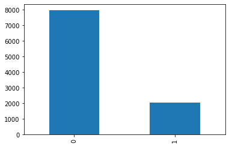

```python
# visual representation of instances per class
data.Exited.value_counts().plot.bar()
```

In the dataset, almost 8000 customers did not leave the bank compared to about 2000 customers that left the bank.

The visual reiterates the imbalance in the dataset which we previously referred to.

```python
# function to plot a boxplot and a histogram along the same scale.


def histogram_boxplot(data, feature, figsize=(12, 7), kde=False, bins=None):
    """
    Boxplot and histogram combined

    data: dataframe
    feature: dataframe column
    figsize: size of figure (default (12,7))
    kde: whether to show the density curve (default False)
    bins: number of bins for histogram (default None)
    """
    f2, (ax_box2, ax_hist2) = plt.subplots(
        nrows=2,  # Number of rows of the subplot grid= 2
        sharex=True,  # x-axis will be shared among all subplots
        gridspec_kw={"height_ratios": (0.25, 0.75)},
        figsize=figsize,
    )  # creating the 2 subplots
    sns.boxplot(
        data=data, x=feature, ax=ax_box2, showmeans=True, color="violet"
    )  # boxplot will be created and a star will indicate the mean value of the column
    sns.histplot(
        data=data, x=feature, kde=kde, ax=ax_hist2, bins=bins, palette="winter"
    ) if bins else sns.histplot(
        data=data, x=feature, kde=kde, ax=ax_hist2
    )  # For histogram
    ax_hist2.axvline(
        data[feature].mean(), color="green", linestyle="--"
    )  # Add mean to the histogram
    ax_hist2.axvline(
        data[feature].median(), color="black", linestyle="-"
    )  # Add median to the histogram
```

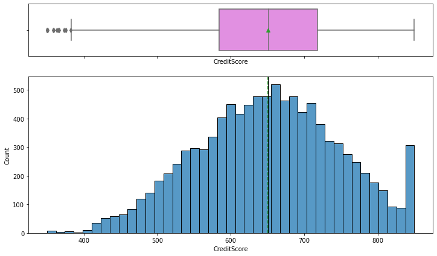

```python
# Observations on CreditScore

histogram_boxplot(data, "CreditScore")
```

The distribution of CreditScore is largely normal with the mean and median around the 650 mark

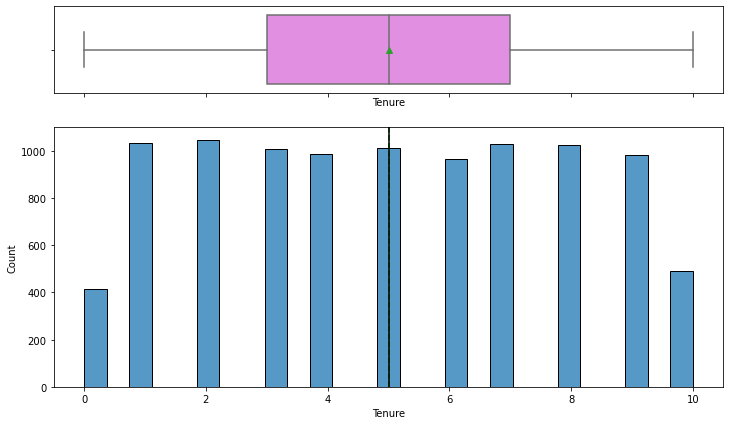

```python
# Observations on Tenure

histogram_boxplot(data, "Tenure")
```

The customers are evenly spread across the different tenure except for 0 and 10.

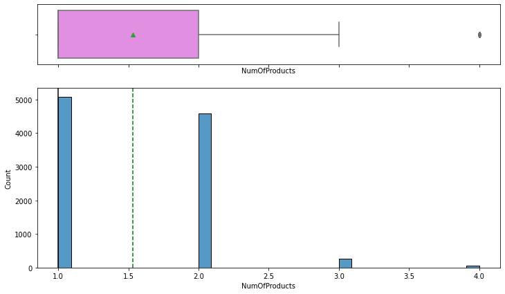

```python
# Observations on NumOfProducts

histogram_boxplot(data, "NumOfProducts")
```

Customers who purchased only 1 product is the predominant group (about 5000) closely followed by customers with 2 products (over 4000).

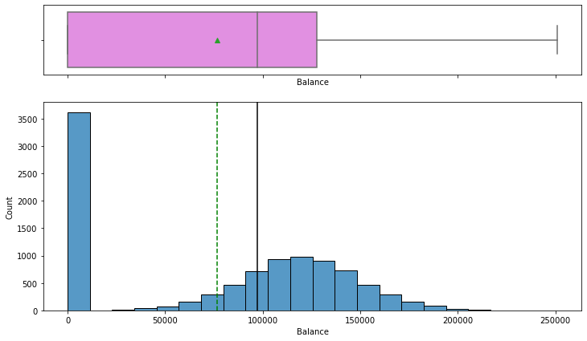

```python
# Observations on Balance

histogram_boxplot(data, "Balance")
```

Over 3500 customers have zero balances. The mean of Balance is above the 70k mark and the median is just shy of 100k

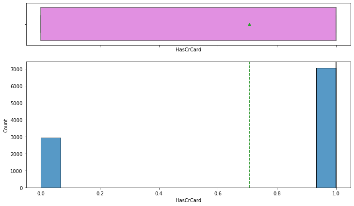

```python
# Observations on HasCrCard

histogram_boxplot(data, "HasCrCard")
```

About 7000 customers have a credit card with the bank compared to 3000 customers without a credit card.

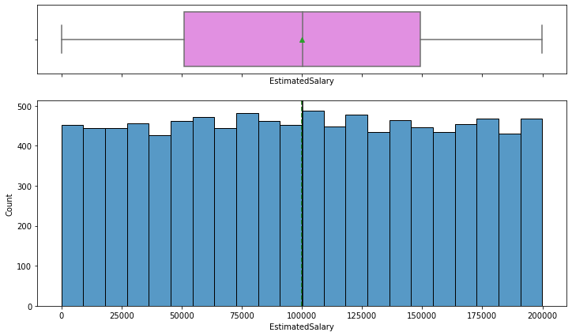

```python
# Observations on EstimatedSalary

histogram_boxplot(data, "EstimatedSalary")
```

The EstimatedSalary is evenly distributed with the mean and median around the 100k mark.

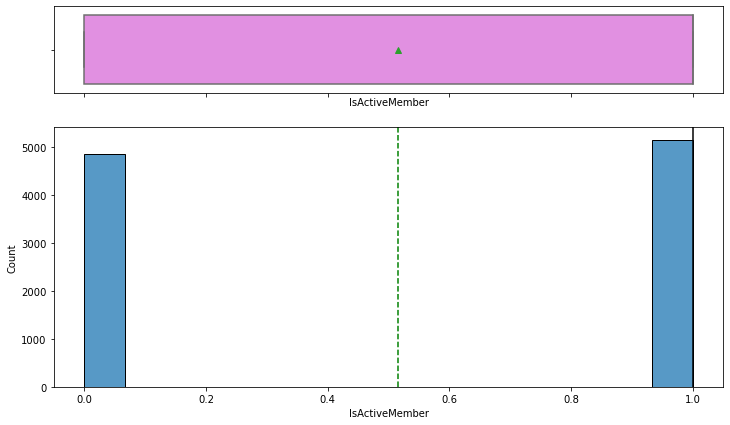

```python
# Observations on IsActiveMember

histogram_boxplot(data, "IsActiveMember")
```

The IsActiveMember is almost evenly spread between customers with active memberships and those without active membership.

```python
print("*********Account Balances likely lost due to churn:************\n")
print("Total balances lost to churn")
print(data.Balance[data.Exited == 1].sum())
print("Mean balance per exit")
print(data.Balance[data.Exited == 1].mean())
print("Compare to current customers:")
print("Total balances from current customers")
print(data.Balance[data.Exited == 0].sum())
print("Mean balance per current customer")
print(data.Balance[data.Exited == 0].mean())
```

```
*********Account Balances likely lost due to churn:************

Total balances lost to churn
185588094.63
Mean balance per exit
91108.53933726063
Compare to current customers:
Total balances from current customers
579270798.25
Mean balance per current customer
72745.29677885193
```

Observation

Customers with balances of over 185m left the bank with an average balance of 91k per exited customer.

Even though only 20% left with a total balance of 185m, the average balance per exited customer is 91k per customer compared to the staying customers (80%) who average 72k per customer despite pooling 579m. The leaving customer group contributed 24% of balance even though they formed 20% of the dataset.

The numbers clearly shows the business sense for building this model to reduce churn. Losing high-balance customers doesn't bode well for a bank as liquidity which comes from account balances is a major revenue earner and is key to sustainability and assessment of Going Concern status in the banking business.

# Bivariate Analysis

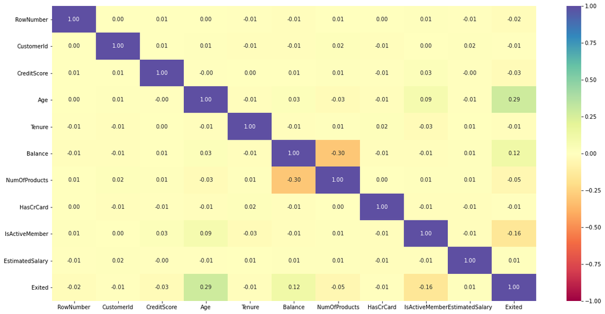

```python
plt.figure(figsize=(20, 10))
sns.heatmap(data.corr(), annot=True, vmin=-1, vmax=1, fmt=".2f", cmap="Spectral")
plt.show()
```

Age has the highest correlation with Exited (0.29). Balance is next (0.12). All others except EstimatedSalary have negative correlation with Exited. IsActiveMember has the highest negative correlatio which is expected as the almost 50:50 split between customers that would leave and customer that stay is not helpful in such analysis.

Balance and NumOfProducts has the highest negative correlation (0.30).

No variable has a high positive correlation with another.

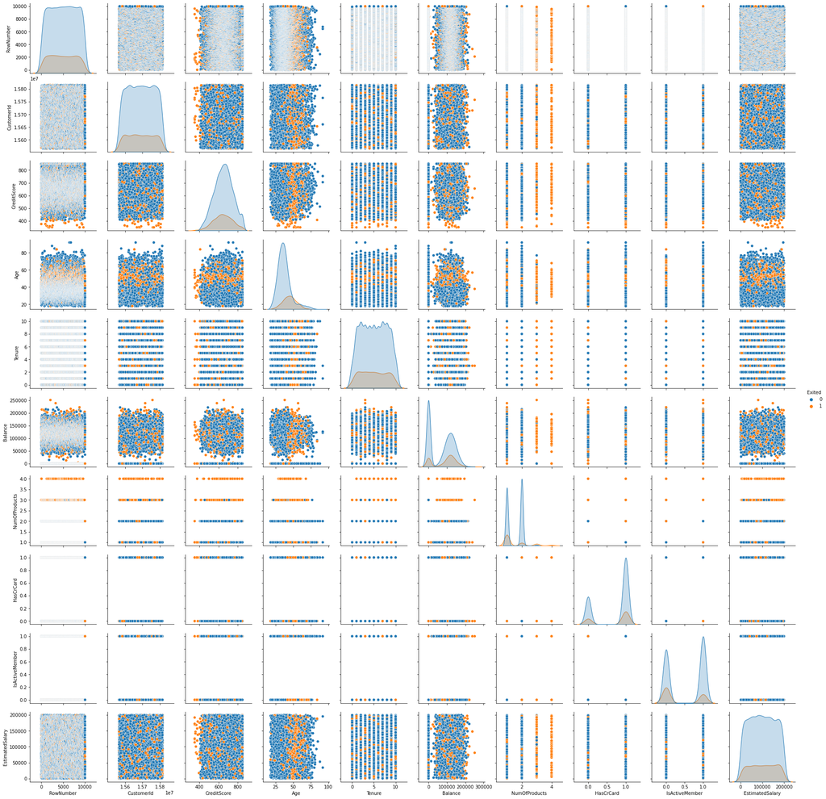

```python
sns.pairplot(data, hue="Exited")
plt.show()
```

We can see varying distributions in these variables, we should investigate it further.

# Exited vs some attributes of customer

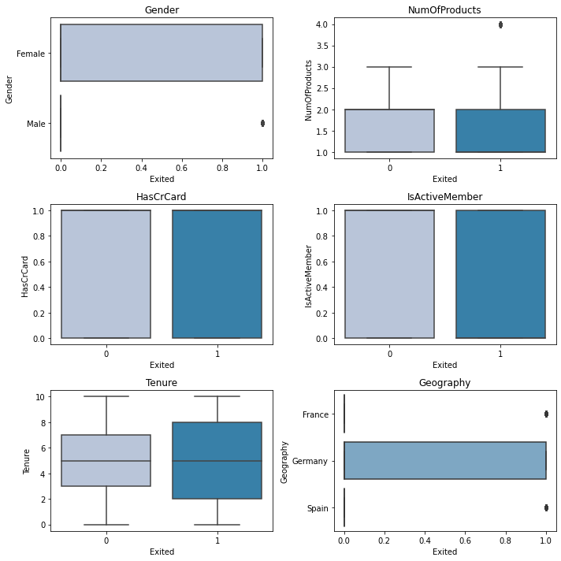

```python
cols = data[
    ["Gender", "NumOfProducts", "HasCrCard", "IsActiveMember", "Tenure", "Geography",]
].columns.tolist()
plt.figure(figsize=(10, 10))

for i, variable in enumerate(cols):
    plt.subplot(3, 2, i + 1)
    sns.boxplot(data["Exited"], data[variable], palette="PuBu")
    plt.tight_layout()
    plt.title(variable)
plt.show()
```

Male customers are more likely to not to leave compared to Female customers which has a wide range between customers that did leave and those that did not leave.

NumOfProducts, IsActiveMember, HasCrCard have an equal spread of customers that did not leave and those that did leave across the range between 0 and 1. A customer who purchased 4 products of the bank did leave which is an anomaly. The purchase of more bank products has not led to loyalty or retention.

Customers in France and Spain are more likely to stay. The bulk of the Exits appear to be in Germany despite not having the majority of customers. Narrowing the issues to what's going on in the branches in Germany is helful in quickly understanding why customers are leaving. Is there a new competitor with better terms, Is there negative press about the bank in Germany? Is there a Government policy responsible for this high churn in Germany?

# Feature Engineering

# One hot encoding

```python
# One-hot encoding of the categorical variables by creating dummy variables
data = pd.get_dummies(data, columns=["Surname", "Geography", "Gender"], drop_first=True)
data.head()
```

|  | RowNumber | CustomerId | CreditScore | Age | Tenure | Balance | NumOfProducts | HasCrCard | IsActiveMember | EstimatedSalary | ... | Surname_Zotova | Surname_Zox | Surname_Zubarev | Surname_Zubareva | Surname_Zuev | Surname_Zuyev | Surname_Zuyeva | Geography_Germany | Geography_Spain | Gender_Male |
| --- | --- | --- | --- | --- | --- | --- | --- | --- | --- | --- | --- | --- | --- | --- | --- | --- | --- | --- | --- | --- | --- |
| 0 | 1 | 15634602 | 619 | 42 | 2 | 0.00 | 1 | 1 | 1 | 101348.88 | ... | 0 | 0 | 0 | 0 | 0 | 0 | 0 | 0 | 0 | 0 |
| 1 | 2 | 15647311 | 608 | 41 | 1 | 83807.86 | 1 | 0 | 1 | 112542.58 | ... | 0 | 0 | 0 | 0 | 0 | 0 | 0 | 0 | 1 | 0 |
| 2 | 3 | 15619304 | 502 | 42 | 8 | 159660.80 | 3 | 1 | 0 | 113931.57 | ... | 0 | 0 | 0 | 0 | 0 | 0 | 0 | 0 | 0 | 0 |
| 3 | 4 | 15701354 | 699 | 39 | 1 | 0.00 | 2 | 0 | 0 | 93826.63 | ... | 0 | 0 | 0 | 0 | 0 | 0 | 0 | 0 | 0 | 0 |
| 4 | 5 | 15737888 | 850 | 43 | 2 | 125510.82 | 1 | 1 | 1 | 79084.10 | ... | 0 | 0 | 0 | 0 | 0 | 0 | 0 | 0 | 1 | 0 |

5 rows × 2945 columns

```python
# Dropping the RowNumber and CustomerId features as they contain unique numbers with no pattern and would add no value to the model.

data = data.drop("RowNumber", axis=1)
data = data.drop("CustomerId", axis=1)
```

There are now 2943 columns after dropping 2 columns.

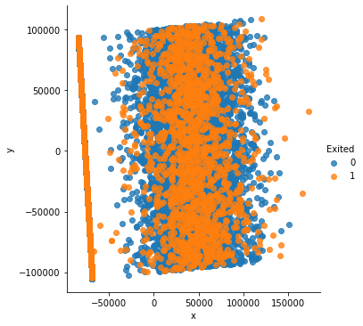

```python
# PCA is performed for visualization only

pca = PCA(n_components=2)
churn_1 = pd.DataFrame(pca.fit_transform(data.iloc[:, 0:10]))
churn_1 = pd.concat([churn_1, data["Exited"]], axis=1)
churn_1.columns = ["x", "y", "Exited"]
sns.lmplot(x="x", y="y", data=churn_1, fit_reg=False, hue="Exited")
```

This Principal Component Analysis(PCA) gives a visualization of the imbalance in the dataset with more blue dots than orange dots.

```python
# function to create labeled barplots


def labeled_barplot(data, feature, perc=True, n=None):
    """
    Barplot with percentage at the top

    data: dataframe
    feature: dataframe column
    perc: whether to display percentages instead of count (default is False)
    n: displays the top n category levels (default is None, i.e., display all levels)
    """

    total = len(data[feature])  # length of the column
    count = data[feature].nunique()
    if n is None:
        plt.figure(figsize=(count + 1, 5))
    else:
        plt.figure(figsize=(n + 1, 5))

    plt.xticks(rotation=90, fontsize=15)
    ax = sns.countplot(
        data=data,
        x=feature,
        palette="Paired",
        order=data[feature].value_counts().index[:n].sort_values(),
    )

    for p in ax.patches:
        if perc == True:
            label = "{:.1f}%".format(
                100 * p.get_height() / total
            )  # percentage of each class of the category
        else:
            label = p.get_height()  # count of each level of the category

        x = p.get_x() + p.get_width() / 2  # width of the plot
        y = p.get_height()  # height of the plot

        ax.annotate(
            label,
            (x, y),
            ha="center",
            va="center",
            size=12,
            xytext=(0, 5),
            textcoords="offset points",
        )  # annotate the percentage

    plt.show()  # show the plot
```

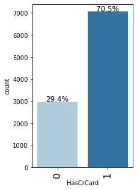

```python
labeled_barplot(data, "HasCrCard")
```

There may be issues around the credit card features like pricing and Customer service which needs to be addressed to reduce churn.

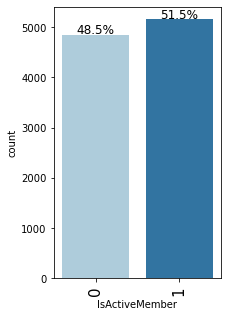

```python
labeled_barplot(data, "IsActiveMember")
```

IsActiveMember does not appear to be a major decider in why customer leave or stay but it clearly does not stop customers leaving.

A key consideration to combine with the IsActiveMember for valuable insights is the number of products that the customer purchased. Let's review NumOfProducts.

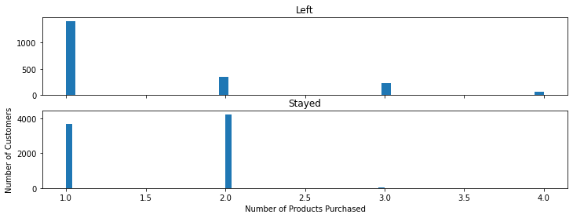

```python
# Histrogram for feature NumOfProducts
f, (ax1, ax2) = plt.subplots(2, 1, sharex=True, figsize=(12, 4))

ax1.hist(data["NumOfProducts"][data["Exited"] == 1], bins=50)
ax1.set_title("Left")

ax2.hist(data["NumOfProducts"][data["Exited"] == 0], bins=50)
ax2.set_title("Stayed")

plt.xlabel("Number of Products Purchased")
plt.ylabel("Number of Customers")
plt.show()
```

Most of the customers that stayed (Over 4000 out of almost 8000) purchased 2 products from the bank.

Purchasing over 2 bank products did not reduce the event of Churn.

Purchasing more than 2 products appear to quicken churn.

```python
# function to plot stacked bar chart


def stacked_barplot(data, predictor, target):
    """
    Print the category counts and plot a stacked bar chart

    data: dataframe
    predictor: independent variable
    target: target variable
    """
    count = data[predictor].nunique()
    sorter = data[target].value_counts().index[-1]
    tab1 = pd.crosstab(data[predictor], data[target], margins=True).sort_values(
        by=sorter, ascending=False
    )
    print(tab1)
    print("-" * 120)
    tab = pd.crosstab(data[predictor], data[target], normalize="index").sort_values(
        by=sorter, ascending=False
    )
    tab.plot(kind="bar", stacked=True, figsize=(count + 1, 5))
    plt.legend(
        loc="lower left", frameon=False,
    )
    plt.legend(loc="upper left", bbox_to_anchor=(1, 1))
    plt.show()
```

```
Exited     0     1    All
Age
All     7963  2037  10000
46       135    91    226
40       343    89    432
43       209    88    297
45       142    87    229
..       ...   ...    ...
79         4     0      4
78         5     0      5
77        10     0     10
76        11     0     11
75         9     0      9

[71 rows x 3 columns]
------------------------------------------------------------------------------------------------------------------------
```

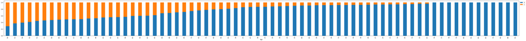

```python
stacked_barplot(data, "Age", "Exited")
```

Most elderly customers did not leave the bank. The focus of the customer retention strategy should be more on keeping younger customers of the bank.

```
Exited     0     1    All
Tenure
All     7963  2037  10000
1        803   232   1035
3        796   213   1009
9        771   213    984
5        803   209   1012
4        786   203    989
2        847   201   1048
8        828   197   1025
6        771   196    967
7        851   177   1028
10       389   101    490
0        318    95    413
------------------------------------------------------------------------------------------------------------------------
```

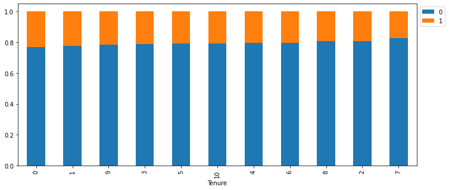

```python
stacked_barplot(data, "Tenure", "Exited")
```

From the dataset, the annual churn figure is +-200. Customers who have spent less than a year are already up to half of this annual churn figure. Additional information would be required to annualize the figure and confirm if this is an improvement (if this dataset was collected close to yearend) or if it is getting worse (if this was collected early in the year e.g a Q1 figure)

```
Exited            0     1    All
NumOfProducts
All            7963  2037  10000
1              3675  1409   5084
2              4242   348   4590
3                46   220    266
4                 0    60     60
------------------------------------------------------------------------------------------------------------------------
```

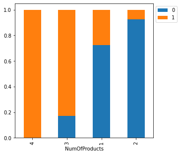

```python
stacked_barplot(data, "NumOfProducts", "Exited")
```

All customers who purchased 4 products left the bank.

The purchase of 2 bank products appears to be the current sweet spot/optimal point to minimize churn as customer who purchase more than 2 products are likely to leave.

A review of the products' features (pricing, competitiveness in the market) may be helpful to understand and buck this trend.

```python
stacked_barplot(data, "Balance", "Exited")
```

```
Exited        0     1    All
Balance
All        7963  2037  10000
0.0        3117   500   3617
12459.19      0     1      1
116973.26     0     1      1
116755.5      0     1      1
...         ...   ...    ...
117864.85     1     0      1
117852.26     1     0      1
85982.07      1     0      1
85996.19      1     0      1
127146.68     1     0      1

[6383 rows x 3 columns]
------------------------------------------------------------------------------------------------------------------------
```

[output not shown]

[output cut: 18 more lines]

[output not shown]

Over 3000 customers who did not leave the bank have a zero account balance compared to only 500 customers that left the bank. This is a 1 for 6 ratio which is very poor. Except they are purchasing other revenue-generating products like overdraft or credit cards, they are not adding much value to the bank and may even increase the total cost by way of cost of maintaining these accounts in a pay-for-storage database and processing time to access information from a large database filled with no-value accounts.

The % of customers staying with low balances may not be giving a true picture of the level of churn. These may be customers who keep their accounts active but have moved their business to another bank hence the Churn problem may be deeper than the categorization in the dataset show.

# Summary of EDA

# Data Description:

# Data Exploration and Cleaning:

# Model Building - Approach

Data preparation

Partition the data into train and test set.

Build model on the train data.

Tune the hyperparameters if required.

Test the data on test set.

If performance is unsatisafctory, try another model and compare performance.

```python
# Seperating the independent and dependent variables into x and y variables respectively in preparation of model building
X = data.drop("Exited", axis=1)
y = data[["Exited"]]
```

```python
# Checking the number of rows and columns in the data

print(X.shape)
print(y.shape)
```

```
(10000, 2942)
(10000, 1)
```

```python
# Let's take a look at the feature1,...,feature2941.
churn_features = data.iloc[:, 1:2942].columns
print(churn_features)
```

```
Index(['Age', 'Tenure', 'Balance', 'NumOfProducts', 'HasCrCard',
       'IsActiveMember', 'EstimatedSalary', 'Exited', 'Surname_Abbie',
       'Surname_Abbott',
       ...
       'Surname_Zotov', 'Surname_Zotova', 'Surname_Zox', 'Surname_Zubarev',
       'Surname_Zubareva', 'Surname_Zuev', 'Surname_Zuyev', 'Surname_Zuyeva',
       'Geography_Germany', 'Geography_Spain'],
      dtype='object', length=2941)
```

```python
# Let's view the dataset to see the new columns and rows
data
```

|  | CreditScore | Age | Tenure | Balance | NumOfProducts | HasCrCard | IsActiveMember | EstimatedSalary | Exited | Surname_Abbie | ... | Surname_Zotova | Surname_Zox | Surname_Zubarev | Surname_Zubareva | Surname_Zuev | Surname_Zuyev | Surname_Zuyeva | Geography_Germany | Geography_Spain | Gender_Male |
| --- | --- | --- | --- | --- | --- | --- | --- | --- | --- | --- | --- | --- | --- | --- | --- | --- | --- | --- | --- | --- | --- |
| 0 | 619 | 42 | 2 | 0.00 | 1 | 1 | 1 | 101348.88 | 1 | 0 | ... | 0 | 0 | 0 | 0 | 0 | 0 | 0 | 0 | 0 | 0 |
| 1 | 608 | 41 | 1 | 83807.86 | 1 | 0 | 1 | 112542.58 | 0 | 0 | ... | 0 | 0 | 0 | 0 | 0 | 0 | 0 | 0 | 1 | 0 |
| 2 | 502 | 42 | 8 | 159660.80 | 3 | 1 | 0 | 113931.57 | 1 | 0 | ... | 0 | 0 | 0 | 0 | 0 | 0 | 0 | 0 | 0 | 0 |
| 3 | 699 | 39 | 1 | 0.00 | 2 | 0 | 0 | 93826.63 | 0 | 0 | ... | 0 | 0 | 0 | 0 | 0 | 0 | 0 | 0 | 0 | 0 |
| 4 | 850 | 43 | 2 | 125510.82 | 1 | 1 | 1 | 79084.10 | 0 | 0 | ... | 0 | 0 | 0 | 0 | 0 | 0 | 0 | 0 | 1 | 0 |
| ... | ... | ... | ... | ... | ... | ... | ... | ... | ... | ... | ... | ... | ... | ... | ... | ... | ... | ... | ... | ... | ... |
| 9995 | 771 | 39 | 5 | 0.00 | 2 | 1 | 0 | 96270.64 | 0 | 0 | ... | 0 | 0 | 0 | 0 | 0 | 0 | 0 | 0 | 0 | 1 |
| 9996 | 516 | 35 | 10 | 57369.61 | 1 | 1 | 1 | 101699.77 | 0 | 0 | ... | 0 | 0 | 0 | 0 | 0 | 0 | 0 | 0 | 0 | 1 |
| 9997 | 709 | 36 | 7 | 0.00 | 1 | 0 | 1 | 42085.58 | 1 | 0 | ... | 0 | 0 | 0 | 0 | 0 | 0 | 0 | 0 | 0 | 0 |
| 9998 | 772 | 42 | 3 | 75075.31 | 2 | 1 | 0 | 92888.52 | 1 | 0 | ... | 0 | 0 | 0 | 0 | 0 | 0 | 0 | 1 | 0 | 1 |
| 9999 | 792 | 28 | 4 | 130142.79 | 1 | 1 | 0 | 38190.78 | 0 | 0 | ... | 0 | 0 | 0 | 0 | 0 | 0 | 0 | 0 | 0 | 0 |

10000 rows × 2943 columns

We have 2943 columns and 10000 rows

```python
# Separating response variable and predictors
X_data = data.iloc[:, 0:2942]
y_data = data.iloc[:, -1]
```

```python
# printing the shape of the data
print(y_data.shape)
print(X_data.shape)
```

```
(10000,)
(10000, 2942)
```

```python
# Let's view dataset after the split into x_data and y_data
X_data
```

|  | CreditScore | Age | Tenure | Balance | NumOfProducts | HasCrCard | IsActiveMember | EstimatedSalary | Exited | Surname_Abbie | ... | Surname_Zotov | Surname_Zotova | Surname_Zox | Surname_Zubarev | Surname_Zubareva | Surname_Zuev | Surname_Zuyev | Surname_Zuyeva | Geography_Germany | Geography_Spain |
| --- | --- | --- | --- | --- | --- | --- | --- | --- | --- | --- | --- | --- | --- | --- | --- | --- | --- | --- | --- | --- | --- |
| 0 | 619 | 42 | 2 | 0.00 | 1 | 1 | 1 | 101348.88 | 1 | 0 | ... | 0 | 0 | 0 | 0 | 0 | 0 | 0 | 0 | 0 | 0 |
| 1 | 608 | 41 | 1 | 83807.86 | 1 | 0 | 1 | 112542.58 | 0 | 0 | ... | 0 | 0 | 0 | 0 | 0 | 0 | 0 | 0 | 0 | 1 |
| 2 | 502 | 42 | 8 | 159660.80 | 3 | 1 | 0 | 113931.57 | 1 | 0 | ... | 0 | 0 | 0 | 0 | 0 | 0 | 0 | 0 | 0 | 0 |
| 3 | 699 | 39 | 1 | 0.00 | 2 | 0 | 0 | 93826.63 | 0 | 0 | ... | 0 | 0 | 0 | 0 | 0 | 0 | 0 | 0 | 0 | 0 |
| 4 | 850 | 43 | 2 | 125510.82 | 1 | 1 | 1 | 79084.10 | 0 | 0 | ... | 0 | 0 | 0 | 0 | 0 | 0 | 0 | 0 | 0 | 1 |
| ... | ... | ... | ... | ... | ... | ... | ... | ... | ... | ... | ... | ... | ... | ... | ... | ... | ... | ... | ... | ... | ... |
| 9995 | 771 | 39 | 5 | 0.00 | 2 | 1 | 0 | 96270.64 | 0 | 0 | ... | 0 | 0 | 0 | 0 | 0 | 0 | 0 | 0 | 0 | 0 |
| 9996 | 516 | 35 | 10 | 57369.61 | 1 | 1 | 1 | 101699.77 | 0 | 0 | ... | 0 | 0 | 0 | 0 | 0 | 0 | 0 | 0 | 0 | 0 |
| 9997 | 709 | 36 | 7 | 0.00 | 1 | 0 | 1 | 42085.58 | 1 | 0 | ... | 0 | 0 | 0 | 0 | 0 | 0 | 0 | 0 | 0 | 0 |
| 9998 | 772 | 42 | 3 | 75075.31 | 2 | 1 | 0 | 92888.52 | 1 | 0 | ... | 0 | 0 | 0 | 0 | 0 | 0 | 0 | 0 | 1 | 0 |
| 9999 | 792 | 28 | 4 | 130142.79 | 1 | 1 | 0 | 38190.78 | 0 | 0 | ... | 0 | 0 | 0 | 0 | 0 | 0 | 0 | 0 | 0 | 0 |

10000 rows × 2942 columns

# Data Pre-processing

```python
# Standardizing the Balance column.
from sklearn.preprocessing import StandardScaler

X_data["normalizedBalances"] = StandardScaler().fit_transform(
    X_data["Balance"].values.reshape(-1, 1)
)  # Normalize 'Balance' in [-1,+1] range
X_data = X_data.drop(["Balance"], axis=1)
```

# Splitting the Data into train and test set in 80:20 ratio

```python
X_train, X_test, y_train, y_test = train_test_split(
    X_data, y_data, test_size=0.2, random_state=7
)
```

```python
print(X_train.shape)
print(X_test.shape)
print(y_train.shape)
print(y_test.shape)
```

```
(8000, 2942)
(2000, 2942)
(8000,)
(2000,)
```

# Model Building

# Random Forest

```python
# Import libraries
from sklearn.ensemble import RandomForestClassifier
```

```python
random_forest = RandomForestClassifier(n_estimators=100)
```

```python
# Pandas Series.ravel() function returns the flattened underlying data as an ndarray.
random_forest.fit(
    X_train, y_train.values.ravel()
)  # np.ravel() Return a contiguous flattened array
```

```
RandomForestClassifier()
```

```python
y_pred = random_forest.predict(X_test)
```

```python
random_forest.score(X_test, y_test)
```

```
0.5565
```

The model's accuracy is 55.65%. This is a poor performance

```python
def make_confusion_matrix(
    cf,
    group_names=None,
    categories="auto",
    count=True,
    percent=True,
    cbar=True,
    xyticks=True,
    xyplotlabels=True,
    sum_stats=True,
    figsize=None,
    cmap="Blues",
    title=None,
):
    """
    This function will make a pretty plot of an sklearn Confusion Matrix cm using a Seaborn heatmap visualization.
    Arguments
    """

    # CODE TO GENERATE TEXT INSIDE EACH SQUARE
    blanks = ["" for i in range(cf.size)]

    if group_names and len(group_names) == cf.size:
        group_labels = ["{}\n".format(value) for value in group_names]
    else:
        group_labels = blanks

    if count:
        group_counts = ["{0:0.0f}\n".format(value) for value in cf.flatten()]
    else:
        group_counts = blanks

    if percent:
        group_percentages = [
            "{0:.2%}".format(value) for value in cf.flatten() / np.sum(cf)
        ]
    else:
        group_percentages = blanks

    box_labels = [
        f"{v1}{v2}{v3}".strip()
        for v1, v2, v3 in zip(group_labels, group_counts, group_percentages)
    ]
    box_labels = np.asarray(box_labels).reshape(cf.shape[0], cf.shape[1])

    # CODE TO GENERATE SUMMARY STATISTICS & TEXT FOR SUMMARY STATS
    if sum_stats:
        # Accuracy is sum of diagonal divided by total observations
        accuracy = np.trace(cf) / float(np.sum(cf))

        # if it is a binary confusion matrix, show some more stats
        if len(cf) == 2:
            # Metrics for Binary Confusion Matrices
            precision = cf[1, 1] / sum(cf[:, 1])
            recall = cf[1, 1] / sum(cf[1, :])
            f1_score = 2 * precision * recall / (precision + recall)
            stats_text = "\n\nAccuracy={:0.3f}\nPrecision={:0.3f}\nRecall={:0.3f}\nF1 Score={:0.3f}".format(
                accuracy, precision, recall, f1_score
            )
        else:
            stats_text = "\n\nAccuracy={:0.3f}".format(accuracy)
    else:
        stats_text = ""

    # SET FIGURE PARAMETERS ACCORDING TO OTHER ARGUMENTS
    if figsize == None:
        # Get default figure size if not set
        figsize = plt.rcParams.get("figure.figsize")

    if xyticks == False:
        # Do not show categories if xyticks is False
        categories = False

    # MAKE THE HEATMAP VISUALIZATION
    plt.figure(figsize=figsize)
    sns.heatmap(
        cf,
        annot=box_labels,
        fmt="",
        cmap=cmap,
        cbar=cbar,
        xticklabels=categories,
        yticklabels=categories,
    )

    if xyplotlabels:
        plt.ylabel("True label")
        plt.xlabel("Predicted label" + stats_text)
    else:
        plt.xlabel(stats_text)

    if title:
        plt.title(title)
```

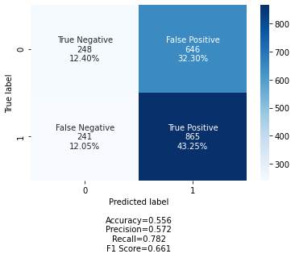

```python
cm3 = confusion_matrix(y_test, y_pred)
labels = ["True Negative", "False Positive", "False Negative", "True Positive"]
make_confusion_matrix(
    cm3,
    group_names=labels,
    # categories=categories,
    cmap="Blues",
)
```

# Model evaluation criterion

The Model can make wrong predictions as:

Predicting a customer leaves the bank and the customer did not leave.

Predicting a customer will not leave the bank and the customer left.

# Which case is more important?

Predicting that the customer will not leave but the customer leaves is more important as wrong predictions would lead to revenue loss and non allocation of resources in engaging customers for timely resolution of service issues that could lead to Churn.

# How to reduce this loss i.e need to reduce False Negative?

The bank would want Recall to be maximized. The greater the Recall, the higher the chances of minimizing false Negative. Hence, the focus should be on increasing Recall or minimizing the false Negative or in other words identifying the True Positive so that the bank can reduce Churn.

# Conclusion:

The number of False positives (646) is high but engagement of customers who are unlikely to leave is not as important as not engaging customers who end up leaving.

Let's see if we can improve this performance with other machine learning / deep learning models.

# Model-1

We will use a simple Neural Network (NN) made of 5 fully-connected layers with ReLu activation. The NN takes a vector of length 2942 as input. This represents the information related to each customers, ie each line with 2942 columns from the dataset.

For each customer, the final layer will output a probability distribution (sigmoid activation function) and classify either as not leaving (0) or leaving (1). A dropout step is included to prevent overfitting.

```python
# initialize the model
model = Sequential()
# This adds the input layer (by specifying input dimension) AND the first hidden layer (units)
model.add(
    Dense(units=16, input_dim=2942, activation="relu")
)  # input of 2942 columns as shown above
# hidden layer
model.add(Dense(units=24, activation="relu"))
# Adding Dropout to prevent overfitting
model.add(Dropout(0.5))
model.add(Dense(24, activation="relu"))
model.add(Dense(24, activation="relu"))
# Adding the output layer
# Notice that we do not need to specify input dim.
# we have an output of 1 node, which is the the desired dimensions of our output churn or not)
# We use the sigmoid because we want probability outcomes
model.add(Dense(1, activation="sigmoid"))  # binary classification churn or not
```

```python
# Creating the optimizer with default learning rate
# Compiling the model
model.compile(optimizer="adam", loss="binary_crossentropy", metrics=["accuracy"])
```

# Let's print the summary of the model

```python
model.summary()
```

```
Model: "sequential_2"
_________________________________________________________________
 Layer (type)                Output Shape              Param #
=================================================================
 dense_8 (Dense)             (None, 16)                47088

 dense_9 (Dense)             (None, 24)                408

 dropout_3 (Dropout)         (None, 24)                0

 dense_10 (Dense)            (None, 24)                600

 dense_11 (Dense)            (None, 24)                600

 dense_12 (Dense)            (None, 1)                 25

=================================================================
Total params: 48,721
Trainable params: 48,721
Non-trainable params: 0
_________________________________________________________________
```

48721 parameters were created

# Training the model using Forward Pass and Backpropagation

```python
# fitting the model using 10 epochs
history = model.fit(X_train, y_train, batch_size=15, epochs=10, validation_split=0.2)
```

Plotting the train and test loss

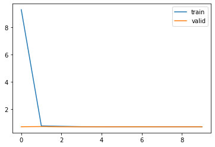

```python
# Capturing learning history per epoch
hist = pd.DataFrame(history.history)
hist["epoch"] = history.epoch

# Plotting accuracy at different epochs
plt.plot(hist["loss"])
plt.plot(hist["val_loss"])
plt.legend(("train", "valid"), loc=0)
```

# Evaluation

Keras model can be evaluated with evaluate() function

Evaluation results are contained in a list

```python
score = model.evaluate(X_test, y_test)
```

```python
print(score)
```

```
[0.6877185106277466, 0.5529999732971191]
```

Let's Print confusion matrix

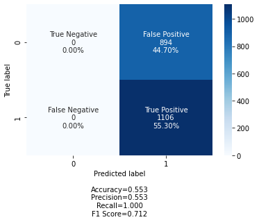

```python
# Confusion Matrix on unseen test set
import seaborn as sn

y_pred1 = model.predict(X_test)
for i in range(len(y_test)):
    if y_pred1[i] > 0.5:
        y_pred1[i] = 1
    else:
        y_pred1[i] = 0


cm2 = confusion_matrix(y_test, y_pred1)
labels = ["True Negative", "False Positive", "False Negative", "True Positive"]
# categories = [ 'Not_Churn','Churn']
make_confusion_matrix(
    cm2,
    group_names=labels,
    # categories=categories,
    cmap="Blues",
)
```

Conclusion:

We must find ways to further reduce the overfitting.

# Model-2

# Training the model using Early Stopping

There are some basic Hyperparameters which can help to reduce wrong predictions like Early Stopping which is a procedure that stops the training process after certain iterations and it appears that the validation dataset is no longer improving but degrading from that point.

```python
# Training Multi-layer perceptron with 2 hidden layers

# adding earlystopping callback
es = keras.callbacks.EarlyStopping(
    monitor="val_loss",
    min_delta=0,
    patience=15,
    verbose=0,
    mode="min",
    restore_best_weights=True,
)

n_inputs = X_train.shape[1]
Model2 = Sequential()
# Initializing the weights uisng hue_normal
Model2.add(
    Dense(
        65, input_shape=(n_inputs,), kernel_initializer="he_normal", activation="relu"
    )
)
Model2.add(Dropout(0.5))
Model2.add(Dense(65, kernel_initializer="he_normal", activation="relu"))
Model2.add(Dropout(0.5))
Model2.add(Dense(1, kernel_initializer="he_normal", activation="sigmoid"))

Model2.compile(
    optimizers.Adam(lr=0.001), loss="binary_crossentropy", metrics=["accuracy"]
)

his_mod2 = Model2.fit(
    X_train,
    y_train,
    validation_split=0.2,
    batch_size=700,
    epochs=40,
    callbacks=[es],
    shuffle=True,
    verbose=1,
)
```

Plotting the train and validation loss

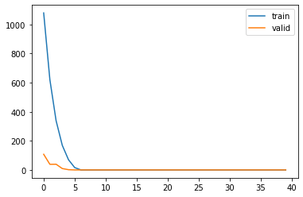

```python
# Capturing learning history per epoch
hist = pd.DataFrame(his_mod2.history)
hist["epoch"] = his_mod2.epoch

# Plotting accuracy at different epochs
plt.plot(hist["loss"])
plt.plot(hist["val_loss"])
plt.legend(("train", "valid"), loc=0)
```

Plotting confusion matrix

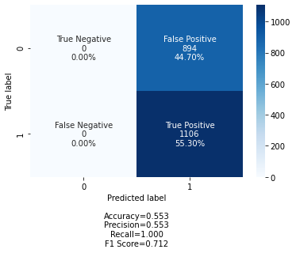

```python
## Confusion Matrix on unseen test set
import seaborn as sn

y_pred1 = Model2.predict(X_test)
for i in range(len(y_test)):
    if y_pred1[i] > 0.5:
        y_pred1[i] = 1
    else:
        y_pred1[i] = 0


cm2 = confusion_matrix(y_test, y_pred1)
labels = ["True Negative", "False Positive", "False Negative", "True Positive"]
categories = ["Not_Churn", "Churn"]
make_confusion_matrix(
    cm2,
    group_names=labels,
    # categories=categories,
    cmap="Blues",
)
```

# Conclusion:

The Accuracy and Recall of the model is unchanged compared to the previous model. The model is overfitting with Recall at 100%. There is no improvement is accuracy too (55.3%).

Being an imbalanced dataset, let's try weighted loss for imbalance dataset to see if we can improve on the overfitting.

# Model -3

# Weighted loss to account for large class imbalance in train dataset

Let's review the process:

```python
from sklearn.utils import class_weight

class_weights = class_weight.compute_class_weight(
    "balanced",
    np.unique(y_train),
    np.array([y_train.iloc[i] for i in range(len(y_train))]),
)
class_weights = class_weight.compute_class_weight(
    class_weight="balanced", classes=np.unique(y_train), y=y_train
)
class_weights = dict(enumerate(class_weights))
class_weights
```

```
{0: 1.0961907371882709, 1: 0.9193288899103654}
```

# Training the model

```python
model.fit(
    X_train, y_train, batch_size=15, epochs=5, class_weight=class_weights, shuffle=True
)
```

```
<keras.callbacks.History at 0x211275e85b0>
```

```python
score_weighted = model.evaluate(X_test, y_test)
```

At 54.9%, accuracy has not improved compared to the previous NN models.

Plotting confusion matrix

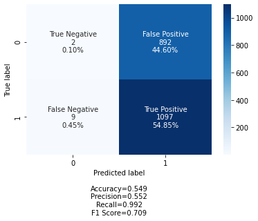

```python
## Confusion Matrix on unseen test set
import seaborn as sn

y_pred1 = model.predict(X_test)
for i in range(len(y_test)):
    if y_pred1[i] > 0.5:
        y_pred1[i] = 1
    else:
        y_pred1[i] = 0


cm2 = confusion_matrix(y_test, y_pred1)
labels = ["True Negative", "False Positive", "False Negative", "True Positive"]
categories = ["Not_Churn", "Churn"]
make_confusion_matrix(
    cm2,
    group_names=labels,
    # categories=categories,
    cmap="Blues",
)
```

# Conclusion:

A high number of False Positives as it is in this case is less important compared to a high number of False Negatives but this can be improved upon hence there is still lot of scope of improvements as follows:

1) Threshold can be tuned to get the optimal value.

2) Resampling techniques can be applied to further balance the data and then train the model.

3) Hyperparameter tuning can be applied to tune the different hyperparameters.

From the EDA, we got the following insights:

1) Even though only 20% left with a total balance of 185m, the average balance per exited customer is 91k per customer compared to the staying customers (80%) who average 72k per customer despite pooling 579m. The leaving customer group contributed 24% of balance even though they formed 20% of the dataset.The numbers clearly shows the business sense for building this model to reduce churn. Losing high-balance customers doesn't bode well for a bank as liquidity which comes from account balances is a major revenue earner and is key to sustainability and assessment of Going Concern status in the banking business.

2) Age has the highest correlation with Exited (0.29). Most elderly customers did not leave the bank. The focus of the customer retention strategy should be more on keeping younger customers of the bank.

5) From the dataset, the annual churn figure is +-200. Customers who have spent less than a year are already up to half of this annual churn figure. Additional information would be required to annualize the figure and confirm if this is an improvement (if this dataset was collected close to yearend) or if it is getting worse (if this was collected early in the year e.g a Q1 figure).

6) The purchase of 2 bank products appears to be the current sweet spot/optimal point to minimize churn as customer who purchase more than 2 products are likely to leave. A review of the products' features (pricing, competitiveness in the market) may be helpful to understand and buck this trend.

7) Over 3000 customers who did not leave the bank have a zero account balance compared to only 500 customers that left the bank. This is a 1 for 6 ratio which is very poor. Except they are purchasing other revenue-generating products like overdraft or credit cards, they are not adding much value to the bank and may even increase the total cost by way of cost of maintaining these accounts in a pay-for-storage database and processing time to access information from a large database filled with no-value accounts. The % of customers staying with low balances may not be giving a true picture of the level of churn. These may be customers who keep their accounts active but have moved their business to another bank hence the Churn problem may be deeper than the categorization in the dataset show.

8) Male customers are more likely to not to leave compared to Female customers which has a wide range between customers that did leave and those that stayed. Products targeted at Female customers should be explored.

9) Customers in France and Spain are more likely to stay. The bulk of the Exits appear to be in Germany despite not having the majority of customers. Narrowing the issues to what's going on in the branches in Germany is helful in quickly understanding why customers are leaving. Is there a new competitor with better terms, Is there negative press about the bank in Germany? Is there a Government policy responsible for this high churn in Germany?